Skip to contents

# The examples of Chapter 3

Muhammad Yaseen

2026-11-10

Source: [`vignettes/VetResearchLMM_04_book_chapter_3.qmd`](https://github.com/myaseen208/VetResearchLMM/blob/HEAD/vignettes/VetResearchLMM_04_book_chapter_3.qmd)

## 1 Abstract

Chapter 3 of the book applies the mixed model to a designed experiment with a covariate (Example 3.1), to the estimation of heritability and breeding values (Example 3.2) and to repeated measures with several covariance structures (Example 3.3). The book prints only part of the data of Examples 3.1 and 3.2, so their analyses run but cannot reproduce the printed numbers; the complete data of Example 3.3 reproduce every printed number.

```r
ref <-
  vlm_reference(
      source   = "Example 3"
    , evaluate = TRUE
    , level    = 1
    )
```

## 2 Example 3.1: doses nested in drug, with a covariate

```r
m1 <-
  vlm_fit(
      fixed    = PCV2 ~ drug + drug:dose
    , data     = ex31
    , random   = ~ drug:herd
    , repeated = NULL
    , method   = c("REML", "ML", "Type3")
    , ddfm     = "satterth"
    , type     = 3
    , class    = c("herd", "dose")
    , bound    = TRUE
    , control  = list()
    )
m1$tests
```

```
      effect num_df   den_df           F         p
      <char>  <int>    <num>       <num>     <num>
1:      drug      1 10.08194 0.001544608 0.9694174
2: drug:dose      1 31.51959 2.600111652 0.1168256
```

```r
vlm_estimate(
    fit    = m1
  , L      = list(
        "Mean Samorin"         = list(Intercept = 1, drug = c(0, 1), "drug:dose" = c(0, 0, 1))
      , "Berenil 2 doses"      = list("drug:dose" = c(1, -1, 0))
      , "Ber vs Sam at dose 1" = list(drug = c(1, -1), "drug:dose" = c(1, 0, -1))
      )
  , random = NULL
  , level  = 0.95
  )
```

```
Estimates (denominator df: satterth)

Estimates
                label estimate    se    df       t      p  lower  upper space
         Mean Samorin    24.17 1.038 15.36   23.28 <1e-04  21.96  26.38 broad
      Berenil 2 doses   -2.102 1.303 31.52  -1.612  0.117 -4.758 0.5548 broad
 Ber vs Sam at dose 1   -1.000 1.468 15.36 -0.6811  0.506 -4.123  2.123 broad

Sources: Duchateau, Janssen and Rowlands (1998); McLean, Sanders and Stroup
(1991); Satterthwaite (1946); Giesbrecht and Burns (1985); Fai and Cornelius
(1996). Full references: vlm_cite(x).
```

Model 3 lets each treatment have its own slope on the PCV at treatment, and compares the treatments for an animal with PCV1 = 18:

```r
m3 <-
  vlm_fit(
      fixed    = PCV2 ~ drug + drug:dose + PCV1:drug:dose
    , data     = ex31
    , random   = ~ drug:herd
    , repeated = NULL
    , method   = c("REML", "ML", "Type3")
    , ddfm     = "kr"
    , type     = 3
    , class    = c("herd", "dose")
    , bound    = TRUE
    , control  = list()
    )
vlm_lsmeans(
    fit    = m3
  , specs  = ~ drug:dose
  , at     = list(PCV1 = 18)
  , diff   = FALSE
  , adjust = c("none", "tukey", "bonferroni", "sidak")
  , level  = 0.95
  )
```

```
Least-squares means (denominator df: kr; 95% limits)

Least squares means
    drug dose estimate    se    df     t      p lower upper
 BERENIL    1    24.20 1.987 29.16 12.18 <1e-04 20.14 28.27
 BERENIL    2    24.79 1.174 13.62 21.11 <1e-04 22.27 27.32
 SAMORIN    1    25.26 2.169 26.49 11.64 <1e-04 20.80 29.71

Sources: Duchateau, Janssen and Rowlands (1998); Searle, Speed and Milliken
(1980); Kenward and Roger (1997). Full references: vlm_cite(x).
```

## 3 Example 3.2: heritability and sire predictions

```r
f32 <-
  vlm_fit(
      fixed    = Ww ~ sex + agew + breed
    , data     = ex32
    , random   = ~ breed:sire_id
    , repeated = NULL
    , method   = c("REML", "ML", "Type3")
    , ddfm     = "satterth"
    , type     = 3
    , class    = "breed"
    , bound    = TRUE
    , control  = list()
    )
f32$covariance
```

```
       parameter subject estimate       se        z            p
          <char>  <char>    <num>    <num>    <num>        <num>
1: breed:sire_id         0.000000       NA       NA           NA
2:      Residual         5.447347 1.020382 5.338539 4.684922e-08
```

```r
vlm_lsmeans(
    fit    = f32
  , specs  = ~ breed
  , at     = NULL
  , diff   = TRUE
  , adjust = "tukey"
  , level  = 0.95
  )$lsmeans
```

```
    breed  estimate        se    df        t            p     lower    upper
   <char>     <num>     <num> <num>    <num>        <num>     <num>    <num>
1:      1 13.123981 0.6055657    57 21.67227 3.343968e-29 11.911357 14.33661
2:      2 12.396055 0.7201282    57 17.21368 3.012048e-24 10.954023 13.83809
3:      3 10.598945 0.8773799    57 12.08022 2.364957e-17  8.842022 12.35587
4:      4 12.740250 0.6569679    57 19.39250 8.957490e-27 11.424695 14.05581
5:      5  9.722305 0.8625235    57 11.27193 3.896394e-16  7.995131 11.44948
6:      6 10.050959 0.9686565    57 10.37618 9.546083e-15  8.111258 11.99066
```

On this part of the data the sire variance is estimated as zero, so the heritability $h^2 = 4\sigma_s^2/ (\sigma_s^2 + \sigma^2)$ is zero; with the complete data the book finds 0.49.

## 4 Example 3.3: covariance structures for repeated measures

Model 1 (a random animal effect, equivalently compound symmetry), Model 2 (first-order autoregressive errors) and Model 3 (a random intercept and slope per animal):

```r
cs <-
  vlm_fit(
      fixed    = PCV ~ breed + breed:time
    , data     = ex33
    , random   = NULL
    , repeated = vlm_repeated(
          type    = c("vc", "cs", "ar1", "sp_pow", "un")[2]
        , subject = ~ animal_id:breed
        , order   = NULL
        )
    , method   = c("REML", "ML", "Type3")
    , ddfm     = c("default", "contain", "residual", "betwithin", "satterth", "kr")
    , type     = 3
    , class    = NULL
    , bound    = TRUE
    , control  = list()
    )
ar <-
  vlm_fit(
      fixed    = PCV ~ breed + breed:time
    , data     = ex33
    , random   = NULL
    , repeated = vlm_repeated(
          type    = c("vc", "cs", "ar1", "sp_pow", "un")[3]
        , subject = ~ animal_id:breed
        , order   = NULL
        )
    , method   = c("REML", "ML", "Type3")
    , ddfm     = c("default", "contain", "residual", "betwithin", "satterth", "kr")
    , type     = 3
    , class    = NULL
    , bound    = TRUE
    , control  = list()
    )
rc <-
  vlm_fit(
      fixed    = PCV ~ breed + breed:time
    , data     = ex33
    , random   = vlm_random(
          effects = ~ 1 + time
        , subject = ~ animal_id:breed
        , type    = c("vc", "un")[2]
        )
    , repeated = NULL
    , method   = c("REML", "ML", "Type3")
    , ddfm     = c("default", "contain", "residual", "betwithin", "satterth", "kr")
    , type     = 3
    , class    = NULL
    , bound    = TRUE
    , control  = list()
    )
rc$covariance
```

```
   parameter         subject     estimate          se         z            p
      <char>          <char>        <num>       <num>     <num>        <num>
1:   UN(1,1) animal_id:breed 12.464572630 6.049874059  2.060303 1.968480e-02
2:   UN(2,1) animal_id:breed -0.255121593 0.142828341 -1.786211 7.406506e-02
3:   UN(2,2) animal_id:breed  0.005758072 0.003777797  1.524188 6.373091e-02
4:  Residual                  4.353042151 0.513010930  8.485282 1.075986e-17
```

```r
cmp <-
  vlm_compare(
      CS   = cs
    , AR1  = ar
    , RC   = rc
    , test = TRUE
    )
cmp
```

```
Comparison of 3 models; smallest AIC: RC

Models
 model method cov_parms   m2ll    AIC   AICC    BIC  chisq df      p p_boundary
    CS   REML         2 783.45 787.45 787.53 788.42         .      .          .
   AR1   REML         2 793.14 797.14 797.21 798.11         .      .          .
    RC   REML         4 767.56 775.56 775.81 777.50 25.583  2 <1e-04          .

Sources: Duchateau, Janssen and Rowlands (1998); Akaike (1974); Schwarz (1978).
Full references: vlm_cite(x).
```

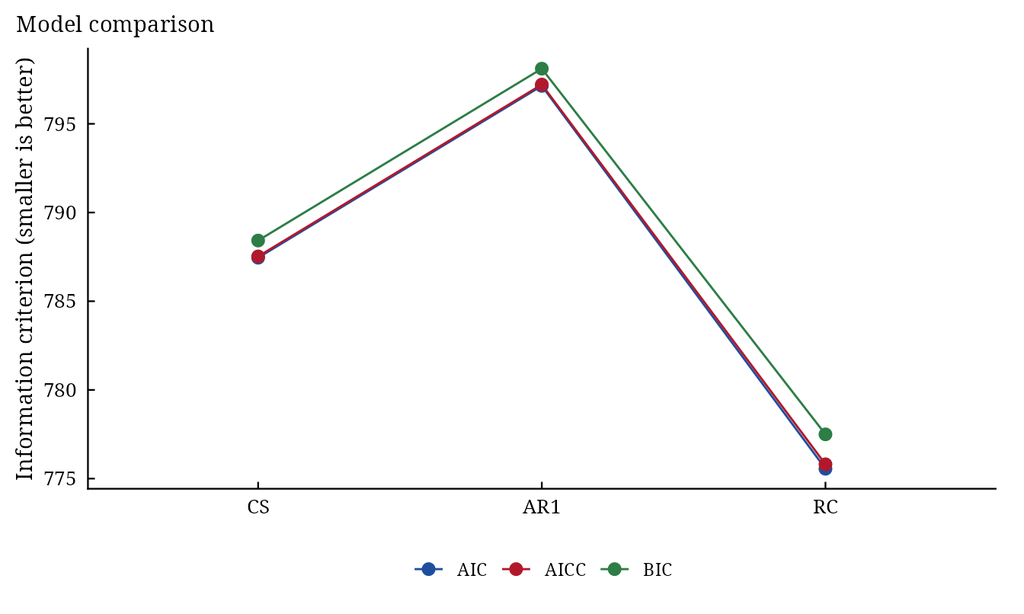

```r
plot(cmp)
```

The book compared Models 1 and 2 only (the restricted log-likelihoods $-391.73$ and $-396.57$ favour compound symmetry); the random coefficients model has a much smaller AIC still, as the negative covariance of the intercepts and slopes (animals that start higher fall faster) suggests.

```r
knitr::kable(x = ref[, c("source", "quantity", "value", "computed", "agrees")], digits = 4,
             col.names = c("Source", "Quantity", "Book", "Computed", "Agrees"))
```

| Source | Quantity | Book | Computed | Agrees |
| --- | --- | --- | --- | --- |
| Duchateau, Janssen and Rowlands (1998), Example 3.3, Model 1 | animal variance | 5.4780 | 5.4785 | TRUE |
| Duchateau, Janssen and Rowlands (1998), Example 3.3, Model 1 | residual variance | 4.9650 | 4.9649 | TRUE |
| Duchateau, Janssen and Rowlands (1998), Example 3.3, Model 1 | fixed effect, row 1 | 35.0600 | 35.0602 | TRUE |
| Duchateau, Janssen and Rowlands (1998), Example 3.3, Model 1 | standard error, row 1 | 1.0560 | 1.0558 | TRUE |
| Duchateau, Janssen and Rowlands (1998), Example 3.3, Model 1 | containment df, row 1 | 10.0000 | 10.0000 | TRUE |
| Duchateau, Janssen and Rowlands (1998), Example 3.3, Model 1 | fixed effect, row 2 | -0.8420 | -0.8420 | TRUE |
| Duchateau, Janssen and Rowlands (1998), Example 3.3, Model 1 | standard error, row 2 | 1.4930 | 1.4931 | TRUE |
| Duchateau, Janssen and Rowlands (1998), Example 3.3, Model 1 | containment df, row 2 | 10.0000 | 10.0000 | TRUE |
| Duchateau, Janssen and Rowlands (1998), Example 3.3, Model 1 | fixed effect, row 4 | -0.4130 | -0.4134 | TRUE |
| Duchateau, Janssen and Rowlands (1998), Example 3.3, Model 1 | standard error, row 4 | 0.0225 | 0.0225 | TRUE |
| Duchateau, Janssen and Rowlands (1998), Example 3.3, Model 1 | containment df, row 4 | 154.0000 | 154.0000 | TRUE |
| Duchateau, Janssen and Rowlands (1998), Example 3.3, Model 1 | fixed effect, row 5 | -0.2760 | -0.2761 | TRUE |
| Duchateau, Janssen and Rowlands (1998), Example 3.3, Model 1 | standard error, row 5 | 0.0225 | 0.0225 | TRUE |
| Duchateau, Janssen and Rowlands (1998), Example 3.3, Model 1 | containment df, row 5 | 154.0000 | 154.0000 | TRUE |
| Duchateau, Janssen and Rowlands (1998), Example 3.3, Model 1 | prediction of animal 3 | -0.6720 | -0.6720 | TRUE |
| Duchateau, Janssen and Rowlands (1998), Example 3.3, Model 1 | prediction of animal 4 | -2.4970 | -2.4967 | TRUE |
| Duchateau, Janssen and Rowlands (1998), Example 3.3, Model 1 | prediction of animal 5 | -2.3830 | -2.3827 | TRUE |
| Duchateau, Janssen and Rowlands (1998), Example 3.3, Model 1 | prediction of animal 2 | 3.0380 | 3.0379 | TRUE |
| Duchateau, Janssen and Rowlands (1998), Example 3.3, Model 1 | prediction of animal 6 | 0.0324 | 0.0324 | TRUE |
| Duchateau, Janssen and Rowlands (1998), Example 3.3, Model 1 | prediction of animal 1 | 2.4810 | 2.4811 | TRUE |
| Duchateau, Janssen and Rowlands (1998), Example 3.3, Model 1 | prediction of animal 7 | -1.6670 | -1.6671 | TRUE |
| Duchateau, Janssen and Rowlands (1998), Example 3.3, Model 1 | prediction of animal 8 | 2.6260 | 2.6264 | TRUE |
| Duchateau, Janssen and Rowlands (1998), Example 3.3, Model 1 | prediction of animal 9 | -1.6670 | -1.6671 | TRUE |
| Duchateau, Janssen and Rowlands (1998), Example 3.3, Model 1 | prediction of animal 10 | -0.3720 | -0.3723 | TRUE |
| Duchateau, Janssen and Rowlands (1998), Example 3.3, Model 1 | prediction of animal 11 | -1.7540 | -1.7543 | TRUE |
| Duchateau, Janssen and Rowlands (1998), Example 3.3, Model 1 | prediction of animal 12 | 2.8340 | 2.8344 | TRUE |
| Duchateau, Janssen and Rowlands (1998), Example 3.3, Model 1 | standard error of prediction | 1.0910 | 1.0912 | TRUE |
| Duchateau, Janssen and Rowlands (1998), Example 3.3, Model 1 | df of the predictions | 154.0000 | 154.0000 | TRUE |
| Duchateau, Janssen and Rowlands (1998), Example 3.3, Model 1 | -2 restricted log-likelihood, compound symmetry | 783.4510 | 783.4514 | TRUE |
| Duchateau, Janssen and Rowlands (1998), Example 3.3, Model 1 | Akaike’s criterion (SAS 6) | -393.7300 | -393.7257 | TRUE |
| Duchateau, Janssen and Rowlands (1998), Example 3.3, Model 1 | Schwarz’s criterion (SAS 6) | -396.8300 | -396.8255 | TRUE |
| Duchateau, Janssen and Rowlands (1998), Example 3.3, Model 1 | null model likelihood ratio chi-square | 80.8450 | 80.8447 | TRUE |
| Duchateau, Janssen and Rowlands (1998), Example 3.3, Model 1 | Type 3 F, row 1 | 470.0500 | 470.0533 | TRUE |
| Duchateau, Janssen and Rowlands (1998), Example 3.3, Model 1 | denominator df, row 1 | 154.0000 | 154.0000 | TRUE |
| Duchateau, Janssen and Rowlands (1998), Example 3.3, Model 1 | Type 3 F, row 2 | 0.3200 | 0.3180 | TRUE |
| Duchateau, Janssen and Rowlands (1998), Example 3.3, Model 1 | denominator df, row 2 | 10.0000 | 10.0000 | TRUE |
| Duchateau, Janssen and Rowlands (1998), Example 3.3, Model 1 | Type 3 F, row 3 | 18.6200 | 18.6168 | TRUE |
| Duchateau, Janssen and Rowlands (1998), Example 3.3, Model 1 | denominator df, row 3 | 154.0000 | 154.0000 | TRUE |
| Duchateau, Janssen and Rowlands (1998), Example 3.3, Model 2 | AR(1) correlation | 0.6210 | 0.6214 | TRUE |
| Duchateau, Janssen and Rowlands (1998), Example 3.3, Model 2 | residual variance | 10.1900 | 10.1898 | TRUE |
| Duchateau, Janssen and Rowlands (1998), Example 3.3, Model 2 | -2 restricted log-likelihood | 793.1390 | 793.1394 | TRUE |
| Duchateau, Janssen and Rowlands (1998), Example 3.3, Model 2 | Akaike’s criterion (SAS 6) | -398.5700 | -398.5697 | TRUE |
| Duchateau, Janssen and Rowlands (1998), Example 3.3, Model 2 | Schwarz’s criterion (SAS 6) | -401.6700 | -401.6696 | TRUE |
| Duchateau, Janssen and Rowlands (1998), Example 3.3, Model 2 | null model likelihood ratio chi-square | 71.1560 | 71.1566 | TRUE |
| Duchateau, Janssen and Rowlands (1998), Example 3.3, Model 3 | UN(1,1) | 12.4600 | 12.4646 | TRUE |
| Duchateau, Janssen and Rowlands (1998), Example 3.3, Model 3 | UN(2,1) | -0.2550 | -0.2551 | TRUE |
| Duchateau, Janssen and Rowlands (1998), Example 3.3, Model 3 | UN(2,2) | 0.0058 | 0.0058 | TRUE |
| Duchateau, Janssen and Rowlands (1998), Example 3.3, Model 3 | residual variance | 4.3530 | 4.3530 | TRUE |
| Duchateau, Janssen and Rowlands (1998), Example 3.3, Model 3 | standard error of the intercept | 1.5010 | 1.5014 | TRUE |
| Duchateau, Janssen and Rowlands (1998), Example 3.3, Model 3 | standard error of breed BO | 2.1230 | 2.1233 | TRUE |
| Duchateau, Janssen and Rowlands (1998), Example 3.3, Model 3 | standard error of a slope | 0.0370 | 0.0375 | TRUE |
| Duchateau, Janssen and Rowlands (1998), Example 3.3, Model 3 | random intercept of BO241 | -1.8360 | -1.8358 | TRUE |
| Duchateau, Janssen and Rowlands (1998), Example 3.3, Model 3 | random slope of BO241 | 0.0563 | 0.0563 | TRUE |
| Duchateau, Janssen and Rowlands (1998), Example 3.3, Model 3 | standard error of a random intercept | 1.6400 | 1.6376 | TRUE |
| Duchateau, Janssen and Rowlands (1998), Example 3.3, Model 3 | standard error of a random slope | 0.0417 | 0.0417 | TRUE |
| Duchateau, Janssen and Rowlands (1998), Example 3.3, Model 3 | df of the predictions | 144.0000 | 144.0000 | TRUE |